# Data analysis figures and results

Julia Wrobel

2022-01-07

# Overview

This file loads produces Figures and runs analysis using the real data.

```r
library(tidyverse)
library(stringr)
library(viridis)
library(splines)
library(refund)
library(Matrix)
library(mvtnorm)
library(patchwork)
library(gridExtra)
library(pracma)
library(tictoc)

knitr::opts_chunk$set(echo = TRUE,
  warning = FALSE,
  fig.width = 9,
  fig.height = 4,
  fig.path = '../figs/'
)

theme_set(theme_bw() + theme(legend.position = "bottom"))

source(here::here("source", "estimate_flode.R"))
source(here::here("source", "utils.R"))
source(here::here("source", "search_alpha.R"))
```

# Load paw data

```r
file_name = paste0("/Users/juliawrobel/Data/201803_hantman_trajectories/data/", "20180418_tidied_data.RDA")

load(file_name)
```

# Data info

Get average lift and grab stats.

```r
paw_position %>%
  filter(type == "Control") %>%
  summarize(mean(lift, na.rm = TRUE), sd(lift, na.rm = TRUE),
            mean(grab, na.rm = TRUE), sd(grab, na.rm = TRUE))
```

```
## # A tibble: 1 × 4
##   `mean(lift, na.rm = TRUE)` `sd(lift, na.rm … `mean(grab, na.… `sd(grab, na.rm…
##                        <dbl>             <dbl>            <dbl>            <dbl>
## 1                      0.768             0.244            0.876            0.240
```

# Data cleaning

Join the datasets

```r
observed_data =
    left_join(
        seq_train %>% select(trial, type, gpfa) %>% unnest(cols = c(gpfa)),
      paw_position %>% unnest(cols = c(paw_position))) %>%
    mutate(sec_since_lift = seconds - lift,
           sec_since_grab = seconds - grab) %>%
    filter(sec_since_lift > -.05, sec_since_lift < .25,
                 type == "Control") %>%
    select(trial, sec_since_lift, px, py, pz) %>%
    gather(key = axis, value = observed, px:pz)
```

It is necessary that the data be evaluated on the same evenly spaced grid for each subject. In order to obtain this I interpolate the data to a different grid.

Also process raw spike trains for plotting. Also look at the paw trajectories before aligning them at the point of lift.

```r
D_paw = 30
make_even_grid = function(data){
    time = seq(-0.05, 0.25, length.out = D_paw)
    even_fit = approx(data$sec_since_lift, data$value, xout = time, rule = 2)$y

    data.frame(sec_since_lift = time, value = even_fit)
}

paw_df =
    left_join(
        seq_train %>% select(trial, type, gpfa) %>% unnest(cols = c(gpfa)),
        paw_position %>% unnest(cols = c(paw_position))) %>%
    mutate(sec_since_lift = seconds - lift) %>%
    filter(sec_since_lift > -.05, sec_since_lift < .25, type == "Control") %>%
    select(trial, type, sec_since_lift, px, py, pz, starts_with("gpfa"))
```

```r
even_paw = paw_df %>%
    select(trial, type, sec_since_lift, starts_with("p")) %>%
    gather(axis, value, starts_with("p")) %>%
    nest(data = c(sec_since_lift, value)) %>%
    mutate(even_data = map(data, make_even_grid)) %>%
    unnest(even_data) %>%
    mutate(time = sec_since_lift - min(sec_since_lift), u = 1) %>%
    select(trial, axis, sec_since_lift, time, u, value)

even_gpfa = paw_df %>%
    select(trial, type, sec_since_lift, starts_with("g")) %>%
    gather(gpfa, value, starts_with("g")) %>%
    nest(data = c(sec_since_lift, value)) %>%
    mutate(even_data = map(data, make_even_grid)) %>%
    unnest(even_data) %>%
    mutate(time = sec_since_lift - min(sec_since_lift)) %>%
    rename(u_gpfa = value) %>%
    select(trial, time, gpfa, u_gpfa) %>%
    spread(gpfa, u_gpfa)


paw_df = left_join(even_paw, even_gpfa)
firing_df =
    left_join(
        seq_train %>% select(trial, type, neuron_fire) %>%
          filter(type == "Control") %>%
          mutate(row = row_number()) %>% unnest(cols = c(neuron_fire)),
        paw_position %>% filter(type == "Control") ) %>%
    #mutate(sec_since_lift = seconds - lift) %>%
    #filter(sec_since_lift > -.05, sec_since_lift < .25) %>%
  filter(seconds < 2) %>%
  #mutate(time = sec_since_lift - min(sec_since_lift)) %>%
    #select(row, trial, type, sec_since_lift, time, seconds, starts_with("loc"))
  arrange(type) %>%
  select(row, trial, seconds, starts_with("loc"))
```

# Analysis

## data organization

We run the model on the three axes separately.

```r
paw_x = paw_df %>%
  filter(axis == "px") %>%
  group_by(trial) %>%
  mutate(int = 1,
         y0 = first(value),
         time = time/0.3)  %>%
  ungroup()

paw_y = paw_df %>%
  filter(axis == "py") %>%
  group_by(trial) %>%
  mutate(int = 1,
         y0 = first(value),
         time = time/0.3)  %>%
  ungroup()

paw_z = paw_df %>%
  filter(axis == "pz") %>%
  group_by(trial) %>%
  mutate(int = 1,
         y0 = first(value),
         time = time/0.3)  %>%
  ungroup()
```

## modeling

First we do a grid search to find the best initial value of $\alpha$. For the grid search we run the model without random effects, choosing a particular value of $\alpha$ and using the observed initial positions to calculate the value of the loss function at that particular $\alpha$.

Run flode on the data and save flode data object. Only run the flode analysis if saved object doesn’t exist.

### px

```r
filename = paste0("/Users/juliawrobel/Documents/projects/2018/201803_Hantman_Trajectories/results/px_results.RData")

if(file.exists(filename)){
    load(filename)
}else{
    tic()
    # initiate alpha
    alpha_start_px = search_alpha(data = paw_x,
                                                         forcing_functions = c("int", "gpfa_1", "gpfa_2", "gpfa_3",
                                                                                                    "gpfa_4", "gpfa_5"),
                                                         Kt = 20)

    # run flode
    px_results = estimate_flode(paw_x,
                                                            alpha0 = alpha_start_px$best_alpha,
                                Kt = 20,
                                                            forcing_functions = c("int", "gpfa_1", "gpfa_2", "gpfa_3",
                                                                                                        "gpfa_4", "gpfa_5"),
                                                            max_iter = 500,
                                                            tol = 0.000001,
                                                            initial_position = TRUE,
                                                            random_effects = TRUE)
    time_px = toc()

    save(px_results, time_px, alpha_start_px, file = filename)
}
```

### py

```r
filename = paste0("/Users/juliawrobel/Documents/projects/2018/201803_Hantman_Trajectories/results/py_results.RData")

if(file.exists(filename)){
    load(filename)
}else{
    tic(quiet = TRUE)
    # initiate alpha
    alpha_start_py = search_alpha(data = paw_y,
                                                         forcing_functions = c("int", "gpfa_1", "gpfa_2", "gpfa_3",
                                                                                                    "gpfa_4", "gpfa_5"),
                                                         Kt = 20)

    # run flode
    py_results = estimate_flode(paw_y,
                                                            alpha0 = alpha_start_py$best_alpha,
                                Kt = 20,
                                                            forcing_functions = c("int", "gpfa_1", "gpfa_2", "gpfa_3",
                                                                                                        "gpfa_4", "gpfa_5"),
                                                            max_iter = 500,
                                                            tol = 0.000001,
                                                            initial_position = TRUE,
                                                            random_effects = TRUE)
    time_py = toc()

    save(py_results, time_py, alpha_start_py, file = filename)
}
```

### pz

```r
filename = paste0("/Users/juliawrobel/Documents/projects/2018/201803_Hantman_Trajectories/results/pz_results.RData")

if(file.exists(filename)){
    load(filename)
}else{
    tic(quiet = TRUE)
    # initiate alpha
    alpha_start_pz = search_alpha(data = paw_z,
                                                         forcing_functions = c("int", "gpfa_1", "gpfa_2", "gpfa_3",
                                                                                                    "gpfa_4", "gpfa_5"),
                                                         Kt = 20)

    # run flode
    pz_results = estimate_flode(paw_z,
                                                            alpha0 = alpha_start_pz$best_alpha,
                                Kt = 20,
                                                            forcing_functions = c("int", "gpfa_1", "gpfa_2", "gpfa_3",
                                                                                                        "gpfa_4", "gpfa_5"),
                                                            max_iter = 500,
                                                            tol = 0.000001,
                                                            initial_position = TRUE,
                                                            random_effects = TRUE)
    time_pz = toc()

    save(pz_results, time_pz, alpha_start_pz, file = filename)
}
```

# Summaries

Below are the computation times for each axis.

- px: 44.58 minutes
- py: 139.21 minutes
- pz: 57.24 minutes

Below are the estimated alpha for each axis:

- px: $\alpha =$ 3.1077197
- py: $\alpha =$ 3.599616
- pz: $\alpha =$ 3.9040678

# Figures

## Figure 1

Below are plots of the paw trajectories and gpfa values.

- Called `fig_data_eda` in the manuscript

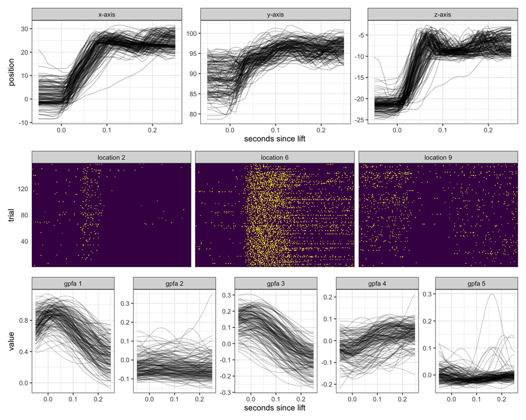

```r
paw_plot = paw_df %>%
  mutate(axis = case_when(
    axis == "px" ~ "x-axis",
    axis == "py" ~ "y-axis",
    axis == "pz" ~ "z-axis"
  )) %>%
    ggplot(aes(sec_since_lift, value, group = trial)) +
    geom_line(alpha = 0.25) +
    labs(x = "seconds since lift", y = "position") +
    facet_wrap(~axis, scales = "free_y") #+
  #theme(axis.title.x = element_blank())

# gonna need to map this to an even grid
neuron_plot = firing_df %>%
    select(row, trial, seconds, loc_02, loc_06, loc_09) %>%
    gather(key = loc, value = value, starts_with("loc")) %>%
    mutate(spike = as.numeric( value > 0),
           loc = str_replace(loc, "loc_0", "location ")) %>%
    ggplot(aes(x = seconds, y = row)) +
    geom_tile(aes(fill = factor(spike))) +
    scale_fill_viridis(discrete = TRUE) +
    #scale_fill_manual(values = c("lightblue", "darkblue")) +
        labs(y = "trial") +
        facet_grid(.~loc) +
    theme(legend.position = "none",
          axis.ticks=element_blank(),
          axis.line=element_blank(),
          axis.text.x = element_blank(),
          axis.title.x = element_blank()) +
    scale_x_continuous(expand=c(0,0)) +
    scale_y_continuous(expand=c(0,0))


gpfa_plot = paw_df %>%
    filter(axis == "px") %>%
    gather(gpfa, x_value, gpfa_1:gpfa_5) %>%
  mutate(gpfa = str_replace(gpfa, "_", " ")) %>%
    ggplot(aes(sec_since_lift, x_value, group = trial)) +
    geom_line(alpha = 0.2) +
    labs(x = "seconds since lift", y = "value") +
    facet_wrap(~ gpfa, scales = "free_y", ncol = 5)


#p1 + (p2 + p3) + p4 + plot_layout(ncol = 1)
(paw_plot + neuron_plot) + gpfa_plot + plot_layout(ncol = 1 )
```

## Figure 6

- Called `fig_data_fits` in the manuscript

### Data org

Combine datasets from the three axes.

```r
x_df = px_results$data %>%
  select(trial, time, value, yhat, delta, deltaStar) %>%
  mutate(axis = "px")

y_df = py_results$data %>%
  select(trial, time, value, yhat, delta, deltaStar) %>%
  mutate(axis = "py")

z_df = pz_results$data %>%
  select(trial, time, value, yhat, delta, deltaStar) %>%
  mutate(axis = "pz")


flode_results = bind_rows(x_df, y_df, z_df) %>%
  mutate(time = time * 0.3)
```

### Plots

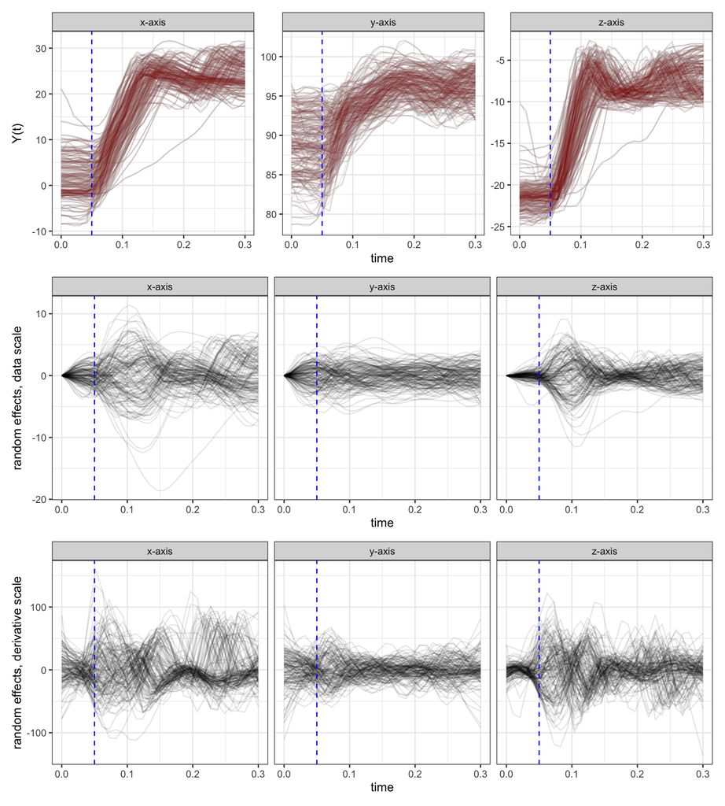

```r
fits = flode_results %>%
      mutate(axis = case_when(
    axis == "px" ~ "x-axis",
    axis == "py" ~ "y-axis",
    axis == "pz" ~ "z-axis"
  )) %>%
  ggplot(aes(time, value, group = trial)) +
  geom_line(alpha = 0.5, color = "gray") +
  geom_line(aes(y = yhat), alpha = 0.1, color = "darkred") +
  geom_vline(xintercept = 0.05, linetype = 2, color = "blue") +
    labs(y = "Y(t)") +
  facet_wrap(~ axis, scales = "free")

delta = flode_results %>%
          mutate(axis = case_when(
    axis == "px" ~ "x-axis",
    axis == "py" ~ "y-axis",
    axis == "pz" ~ "z-axis"
  )) %>%
  ggplot(aes(time, delta, group = trial)) +
  geom_line(alpha = 0.1) +
  geom_vline(xintercept = 0.05, linetype = 2, color = "blue") +
    labs(y = "random effects, derivative scale") +
  facet_wrap(~ axis)

deltaStar = flode_results %>%
          mutate(axis = case_when(
    axis == "px" ~ "x-axis",
    axis == "py" ~ "y-axis",
    axis == "pz" ~ "z-axis"
  )) %>%
  ggplot(aes(time, deltaStar, group = trial)) +
  geom_line(alpha = 0.1) +
  geom_vline(xintercept = 0.05, linetype = 2, color = "blue") +
    labs(y = "random effects, data scale") +
  facet_wrap(~ axis)

fits  +  deltaStar + delta  + plot_layout(ncol = 1)
```

## Figure 7

- Called `fig_data_beta` in the manuscript

### Data org

```r
# betas
beta_results = bind_rows(px_results$beta %>% mutate(axis = "px"),
          py_results$beta %>% mutate(axis = "py"),
          pz_results$beta %>% mutate(axis = "pz")) %>%
  mutate(time = time * 0.3)
```

### Plot

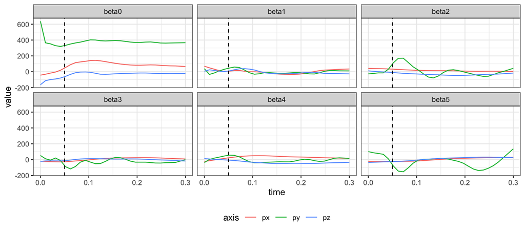

```r
beta_results %>%
  gather(beta, value, starts_with("beta"))  %>%
  ggplot(aes(time, value, group = axis, color = axis)) +
    geom_line() +
  geom_vline(xintercept = 0.05, linetype = 2, color = "black") +
  facet_wrap(~ beta) +
  theme(legend.position = "bottom")
```

## Figure 8

- Called `fig_data_surfaces` in the manuscript

### Data org

```r
## for surfaces just look at paw X
# now get surfaces
make_surface_df = function(data, beta_num){
  surface = data$surface[[beta_num]]


  surface %>% as_tibble() %>%
    mutate(t = attributes(surface)$t) %>%
    gather(s, value, starts_with("s")) %>%
    arrange(t) %>%
    mutate(s = rep(attributes(surface)$s, 30),
           label = paste0("beta", beta_num - 1))
}

surface_df = map_dfr(2:6, make_surface_df, data = px_results)
```

### Plot

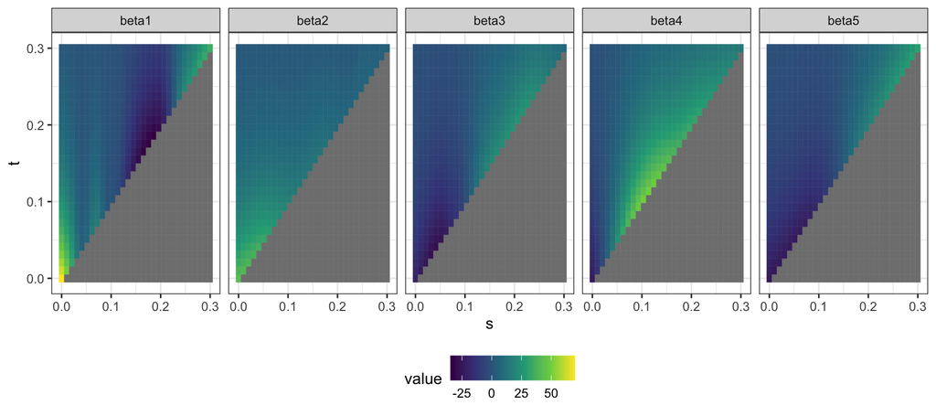

```r
surface_df %>%
  mutate(value = ifelse(s <= t, value, NA),
         s = s * 0.3,
         t = t * 0.3) %>%
  ggplot(aes(s, t)) +
  geom_tile(aes(fill = value, col = value)) +
  scale_fill_viridis_c() +
  scale_colour_viridis_c() +
  facet_wrap(~ label, , ncol = 5) +
  theme(legend.position = "bottom")
```